# GCDS Homework #07

Due: 10-20-2022

**Overview**

This homework involves a lot of redundancy for evaluating two models so once you figure out the first model, the second will be very similar.

You will save the `R Markdown` homework document and save it to “GCDS/r” on your computer. Rename as **“GCDS_HW_07_yourname”**. When you open it, add your name to the author part of the YAML code. The homework will need to be submitted as a `knit` HTML file. Feel free to work with a partner but understand that the work submitted has to be your own.

*NOTE: The plots may take a moment to render as there is a lot of data.*

# 1 **Load Libraries**

Load libraries for plots, data manipulation, and model interpretation (e.g., `performance` and `parameters`).

```r
library(dplyr)
```

```r
library(ggplot2)
library(performance)
library(parameters)
```

# 2 **Getting Data**

Take the `diamonds` data from `ggplot2` and select out the variables `x`, `y`, and `z` and assign the data frame to `diamond`.

```r
diamond <- diamonds %>% select(., -c(x,y,z))
```

# 3 **Summarize the Data**

What is the mean price for all diamonds?

```r
# grand mean
diamond %>%
  summarise(., price = mean(price))
```

```
## # A tibble: 1 × 1
##   price
##   <dbl>
## 1 3933.
```

# 4 **Correlation Matrix**

Select the numeric variables in `diamond` and pass that to `cor()` in order to view the correlation matrix of linear relationships between variables.

```r
diamond %>%
  select(., where(is.numeric)) %>%
  cor(.)
```

```
##            carat       depth      table      price
## carat 1.00000000  0.02822431  0.1816175  0.9215913
## depth 0.02822431  1.00000000 -0.2957785 -0.0106474
## table 0.18161755 -0.29577852  1.0000000  0.1271339
## price 0.92159130 -0.01064740  0.1271339  1.0000000
```

# 5 **Visualize a Model**

Use `ggplot2` to plot `price` as a function of `carat`.

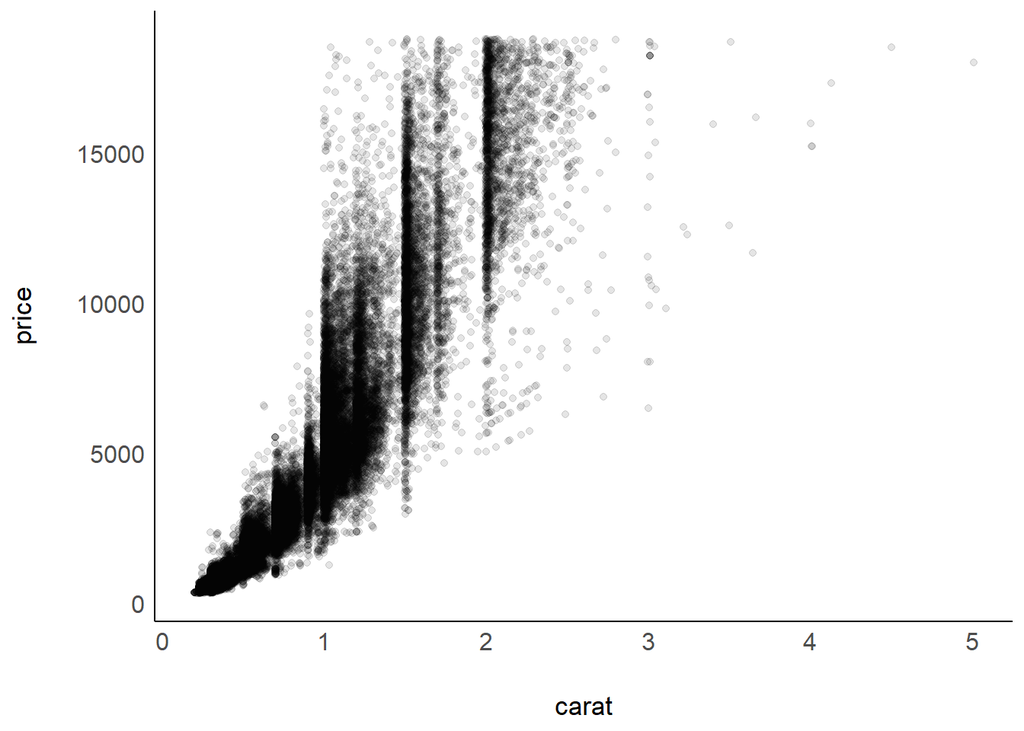

```r
diamond %>%
  ggplot(., aes(carat, price)) +
  geom_jitter(alpha = .1) +
  see::theme_modern()
```

```r
#diamond %>%
#  ggplot(., aes(carat, price)) +
#  stat_summary(geom = "pointrange") +
#  see::theme_modern()
```

# 6 **Simple Linear Regression**

Build a simple linear model that predicts `price` from `carat` size.

```r
lm_carat <- diamond %>%
  lm(price ~ carat, data = .)
```

# 7 **Check the Model Assumptions**

Use `check_collinearity()`, `check_normality()`, `check_heteroscedasticity()`, `check_outliers()` from the `performance` library to check any necessary assumptions.

```r
check_normality(lm_carat)
check_heteroscedasticity(lm_carat)
check_outliers(lm_carat)
```

```
## OK: No outliers detected.
```

*Summary*: Describe what do you find.

# 8 **Check the Model Parameters and Performance Metrics**

Using `summary()`, `model_parameters()`, or `model_performance()` to assess the model and then complete the following statements by entering the relevant values.

```r
summary(lm_carat)
```

```
##
## Call:
## lm(formula = price ~ carat, data = .)
##
## Residuals:
##      Min       1Q   Median       3Q      Max
## -18585.3   -804.8    -18.9    537.4  12731.7
##
## Coefficients:
##             Estimate Std. Error t value Pr(>|t|)
## (Intercept) -2256.36      13.06  -172.8   <2e-16 ***
## carat        7756.43      14.07   551.4   <2e-16 ***
## ---
## Signif. codes:  0 '***' 0.001 '**' 0.01 '*' 0.05 '.' 0.1 ' ' 1
##
## Residual standard error: 1549 on 53938 degrees of freedom
## Multiple R-squared:  0.8493, Adjusted R-squared:  0.8493
## F-statistic: 3.041e+05 on 1 and 53938 DF,  p-value: < 2.2e-16
```

```r
model_parameters(lm_carat)
```

```
## Parameter   | Coefficient |    SE |               95% CI | t(53938) |      p
## ----------------------------------------------------------------------------
## (Intercept) |    -2256.36 | 13.06 | [-2281.95, -2230.77] |  -172.83 | < .001
## carat       |     7756.43 | 14.07 | [ 7728.86,  7784.00] |   551.41 | < .001
```

```
##
## Uncertainty intervals (equal-tailed) and p-values (two-tailed) computed
##   using a Wald t-distribution approximation.
```

```r
model_performance(lm_carat)
```

```
## # Indices of model performance
##
## AIC       |       BIC |    R2 | R2 (adj.) |     RMSE |    Sigma
## ---------------------------------------------------------------
## 9.455e+05 | 9.455e+05 | 0.849 |     0.849 | 1548.533 | 1548.562
```

*Summary*: The percentage of variance in `price` that is explained by variation in `carat` size is _____. Although not realistic, based on the model the price for a diamond of `carat` size = 0 would be ____. For each unit increases/decreases in `carat` size, `price` of the diamond increases by ___ dollars.

# 9 **Multiple Predictors**

Now add a diamond’s `table` characteristic to the model. You can specify the predictor in a completely new model if that is easy for you.

Alternatively, you can use `update()` to take an existing model and update it with new variable. If the outcome varible is the same, a `.` would take the place of the original outcome variable to the left of the `~`. To keep the first predictor the same, use `.` in place of it after the `~` but then add the other predictors.

Example: `update(old model, . ~ . + new predictor, data = diamond)`

```r
lm_carat_table <- update(lm_carat, . ~ . + table, data = diamond)

#lm_carat_table <- diamond %>%  lm(price ~ carat + table + depth, data = .)
```

# 10 **Check the Model Assumptions**

```r
check_collinearity(lm_carat_table)
```

```
## # Check for Multicollinearity
##
## Low Correlation
##
##   Term  VIF   VIF 95% CI Increased SE Tolerance Tolerance 95% CI
##  carat 1.03 [1.03, 1.04]         1.02      0.97     [0.96, 0.97]
##  table 1.03 [1.03, 1.04]         1.02      0.97     [0.96, 0.97]
```

```r
check_normality(lm_carat_table)
check_heteroscedasticity(lm_carat_table)
check_outliers(lm_carat_table)
```

```
## OK: No outliers detected.
```

# 11 **Check the Model Parameters and Performance Metrics**

Using `summary()`, `model_parameters()`, or `model_performance()` to assess the model and then complete the following statements by entering the relevant values.

```r
summary(lm_carat_table)
```

```
##
## Call:
## lm(formula = price ~ carat + table, data = diamond)
##
## Residuals:
##      Min       1Q   Median       3Q      Max
## -18738.6   -795.2    -30.1    529.0  12608.0
##
## Coefficients:
##             Estimate Std. Error t value Pr(>|t|)
## (Intercept) 1961.992    171.811   11.42   <2e-16 ***
## carat       7820.038     14.225  549.74   <2e-16 ***
## table        -74.301      3.018  -24.62   <2e-16 ***
## ---
## Signif. codes:  0 '***' 0.001 '**' 0.01 '*' 0.05 '.' 0.1 ' ' 1
##
## Residual standard error: 1540 on 53937 degrees of freedom
## Multiple R-squared:  0.851,  Adjusted R-squared:  0.851
## F-statistic: 1.54e+05 on 2 and 53937 DF,  p-value: < 2.2e-16
```

```r
model_parameters(lm_carat_table)
```

```
## Parameter   | Coefficient |     SE |             95% CI | t(53937) |      p
## ---------------------------------------------------------------------------
## (Intercept) |     1961.99 | 171.81 | [1625.24, 2298.74] |    11.42 | < .001
## carat       |     7820.04 |  14.22 | [7792.16, 7847.92] |   549.74 | < .001
## table       |      -74.30 |   3.02 | [ -80.22,  -68.39] |   -24.62 | < .001
```

```
##
## Uncertainty intervals (equal-tailed) and p-values (two-tailed) computed
##   using a Wald t-distribution approximation.
```

```r
model_performance(lm_carat_table)
```

```
## # Indices of model performance
##
## AIC       |       BIC |    R2 | R2 (adj.) |     RMSE |    Sigma
## ---------------------------------------------------------------
## 9.449e+05 | 9.449e+05 | 0.851 |     0.851 | 1539.903 | 1539.946
```

*Summary*: The percentage of variance in `price` that is explained by the predictors is _____. Although not realistic, based on the model the price for a diamond of `carat` size = 0 would be ____. For each unit increase in diamond `carat` size, `price` of the diamond increases/decreases by ___ dollars when controlling for (or holding constant) `table` size. Also, for each unit increase in a diamond’s `table`, it’s price increases/decreases by ___ dollars when controlling for (or holding constant) `carat` size.

*Comment*:

Does the estimate associated with `carat` change across the two models? If so, how?

Does holding constant the role of `carat` size affect relationship between `table` and `price`? Hint: Look at the correlation matrix?

# 12 **Compare the Models**

Use `compare_performance()` from the `performance` library to compare your two models.

```r
compare_performance(lm_carat, lm_carat_table, rank = T)
```

```
## # Comparison of Model Performance Indices
##
## Name           | Model |    R2 | R2 (adj.) |     RMSE |    Sigma | AIC weights | BIC weights | Performance-Score
## ----------------------------------------------------------------------------------------------------------------
## lm_carat_table |    lm | 0.851 |     0.851 | 1539.903 | 1539.946 |        1.00 |        1.00 |           100.00%
## lm_carat       |    lm | 0.849 |     0.849 | 1548.533 | 1548.562 |   3.24e-131 |   2.77e-129 |             0.00%
```

*Summary*: Does one have a higher R-squared value?; a lower AIC or BIC value?; a lower RMSE value? If so, is one a better model?

**Upload Submission**: Make sure you have named your file correctly, knit it to html (click icon in RStudio) and upload file [here](https://claremontmckenna.app.box.com/f/80863fd8e0f44ec7a95882d9dda8bb91).

```r
message(paste0("knit by ", usr_time))
```

```
## knit by gcook: sun oct 16 23:03:32 2022
```